# CSE3505 FOUNDATION OF DATA ANALYTICS J COMPONENT REPORT

2022-11-16

## TITLE: STATISTICAL ANALYSIS OF LIVING IN CANADA

TEAM MEMBERS:

20BPS1137 - KANCHARLA NAVEEN KUMAR

20BPS1142 - DIPANSU ROUT

PROBLEM STATEMENT:

Our main goal in analyzing the data sets comes down to see how multiple variables in a data set affects each other. As we already saw by analyzing cost of living and quality of living differs greatly cities to cities when compared on large scale data like healthcare, expenditure etc. Then we take the whole world for comparison on GDP basis while coming down to focus on a single country like Canada because many factors play role in its statistics being one of the highest in the world.

DATA SOURCE:

https://data.world/atbventures/qualityoflife

https://data.world/atbventures/qualityoflife/workspace/file?filename=GDP_World.csv

https://data.world/atbventures/qualityoflife/workspace/file?filename=HealthSpending_byprovince.csv

https://data.world/atbventures/qualityoflife/workspace/file?filename=GDP_World_10yr_weightedaverage.csv

https://data.world/atbventures/qualityoflife/workspace/file?filename=stats_expenseindicators_canada_province.csv

OBJECTIVES:

GDP enables policymakers and central banks to judge whether the economy is contracting or expanding and promptly take necessary action. It also allows policymakers, economists, and businesses to analyze the impact of variables such as monetary and fiscal policy, economic shocks, and tax and spending plans.

Health-related quality of life (HRQL) focuses on the impact of health on a person’s ability to live a fulfilling life. HRQL represents a broad concepts of physical, psychological with social functioning and well-being that includes both positive and negative aspects.

Government spends a considerable portion of its income towards provision of social security benefits such as unemployment allowances old age pension, insurance benefits, sickness benefit, medical benefit, etc. Such benefits reduce the desire to work. In other words they act as disincentive to work.

ANALYSIS:

Gross domestic product tracks the health of a country’s economy. It represents the value of all goods and services produced over a specific time period within a country’s borders. Economists can use GDP to determine whether an economy is growing or experiencing a recession. Investors can use GDP to make investments decisions—a bad economy often means lower earnings and stock prices. Healthcare expenditure can result in better provision of health opportunities, which can strengthen human capital and improve the productivity, thereby contributing to economic performance. It is therefore important to assess the phenomenon of healthcare spending in a country.

IMPORTING THE NECESSARY LIBRARIRES:

```r
library(dplyr)
```

```r
library(ggplot2)
```

READING THE DATA AND GIVING A DESCRIPTION OF THE DATA.

Analyzing global per capita GDP provides insight into global economic prosperity and developments. Small,rich and more developed industrial countries tend to have the highest per capita GDP.

WHEN THE NA VALUES ARE PRESENT IT SHOULD BE CLEANED USING ANY OF THE CLEANING METHODS. AND HERE NA.OMIT IS USED.

```r
df3 <- read.csv('GDP_World.csv')
dim(df3)
```

```
## [1] 8190    3
```

```r
sum(is.na(df3)) #THERE ARE NA VALUES PRESENT USE COMPLETE.CASES AND CLEAN THE DATA
```

```
## [1] 681
```

```r
df3_clean <- na.omit(df3)
sum(is.na(df3_clean)) #DATA IS CLEANED
```

```
## [1] 0
```

```r
dim(df3_clean)
```

```
## [1] 7509    3
```

```r
View(df3_clean)
```

STATISTICAL ANALYSIS SHOWS THE SITUATION OF MANY COUNTRIES COMPARED TO THE MEAN VALUE OF GDP AND GDP PER CAPITA

```r
#STATISTICAL ANALYSIS

summary(df3_clean)
```

```
##    Country               Year      GDP_percapita
##  Length:7509        Min.   :1980   Min.   :    17.12
##  Class :character   1st Qu.:1993   1st Qu.:   968.15
##  Mode  :character   Median :2004   Median :  3200.97
##                     Mean   :2003   Mean   :  9675.70
##                     3rd Qu.:2014   3rd Qu.: 10981.92
##                     Max.   :2024   Max.   :132701.60
```

```r
#YOU CAN SEE THAT THE MAX GDP PER CAPITA IS 132701 AND LUXEMBOURG IS HAVING THE HIGHEST GDP PER CAPITA AND MEAN GDP PER CAPITA IS 9675 WHICH SHOWS THATS THERE ARE MANY COUNTRIES LYING UNDER THE MARGIN GDP PER CAPITA AND THE MINIMUM GDP PER CAPITA IS 17.12 WHICH SHOWS THAT COMBODIA IS HAVING THE MINIMUM GDP PER CAPITA
```

MANIPULATING THE DATA FOR THE VISUALISATION. ANALYZING AS PER YEAR AND COMPARING WITH PREVIOUS YEARS. STATISTICAL ANALYSIS SHOWS HOW IN RECENT YEARS THE MEAN GDP CHANGED EITHER INCREASED OR DECREASED. AND IT SHOWS THAT WHAT COUNTRY IS HAVING MAXIMUM AND MINIMUM GDP.

```r
DF1 <- subset(df3_clean,df3_clean$Year==2018)
summary(DF1)
```

```
##    Country               Year      GDP_percapita
##  Length:181         Min.   :2018   Min.   :   307
##  Class :character   1st Qu.:2018   1st Qu.:  2038
##  Mode  :character   Median :2018   Median :  6013
##                     Mean   :2018   Mean   : 14498
##                     3rd Qu.:2018   3rd Qu.: 17464
##                     Max.   :2018   Max.   :115536
```

```r
#MEAN VALUE IS 14498 WHICH IS AVERAGE GDP PER CAPITA COMPARED TO MAXIMUM GDP PER CAPITA

#WORLD GDP IN THE YEAR 2022 WITH THE YEAR 2018
df4 <- subset(df3_clean,df3_clean$Year==2022)
summary(df4)
```

```
##    Country               Year      GDP_percapita
##  Length:179         Min.   :2022   Min.   :   323.7
##  Class :character   1st Qu.:2022   1st Qu.:  2581.2
##  Mode  :character   Median :2022   Median :  6876.6
##                     Mean   :2022   Mean   : 16049.9
##                     3rd Qu.:2022   3rd Qu.: 20019.0
##                     Max.   :2022   Max.   :124467.1
```

```r
#YOU CAN SEE THAT MEAN GDP PER CAPITA IS INCREASED OVER THE YEARS

DF <- subset(df3_clean,df3_clean$Year==2024)
summary(DF)
```

```
##    Country               Year      GDP_percapita
##  Length:179         Min.   :2024   Min.   :   347.2
##  Class :character   1st Qu.:2024   1st Qu.:  2841.3
##  Mode  :character   Median :2024   Median :  7289.0
##                     Mean   :2024   Mean   : 17403.0
##                     3rd Qu.:2024   3rd Qu.: 21429.2
##                     Max.   :2024   Max.   :132701.6
```

```r
#IT SHOWS THAT THERE WILL BE A GRADUAL INCREASE IN MEAN GDP PER CAPITA WHICH SHOWS THAT THERE ARE SOME GOOD DEVELOPMENTS HAPPENING IN MANY COUNTRIES

df5 <- head(df4,15)
```

VISUALISATION ON THE DATA SET TAKEN. VISUALIZING USING HISTOGRAM AND SCATTER PLOT AND INFERING THE RESULTS

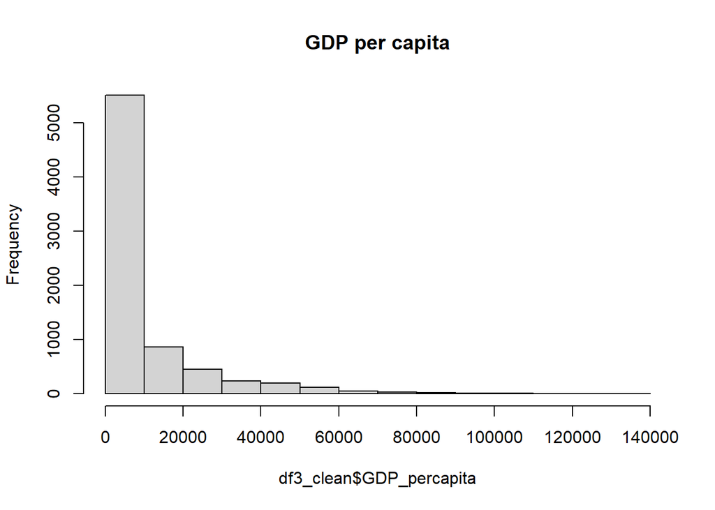

```r
hist(df3_clean$GDP_percapita, main="GDP per capita")
```

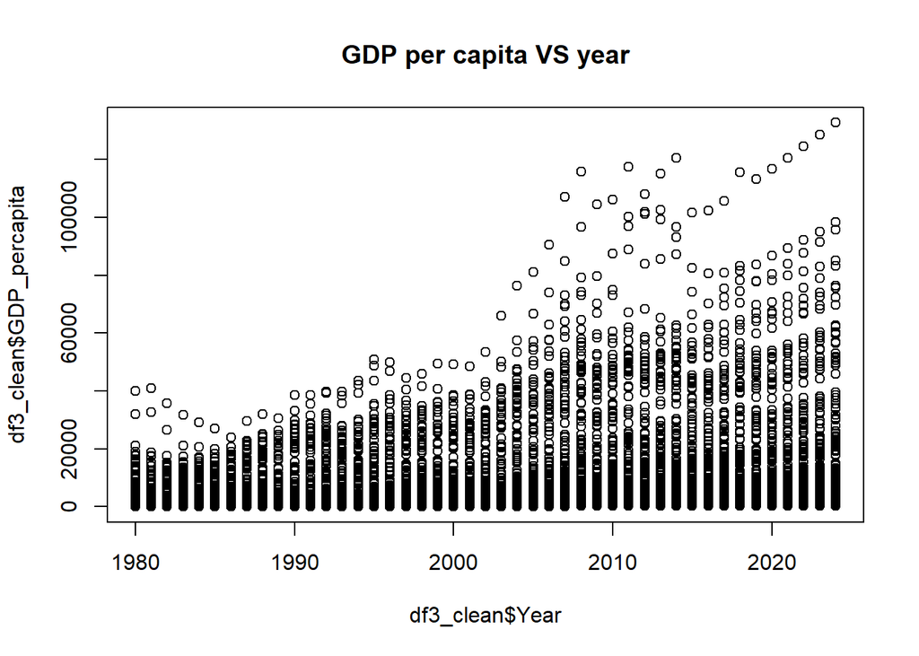

```r
#THERE ARE MANY COUNTRIES UNDER 10000 GDP PER CAPITA AND FOLLOWED BY FEWER COUNTRIES IN THE RANGE OF 20000 TO 80000 WHICH SHOWS THAT MANY COUNTRIES ARE STILL IN DEVELOPING STAGE

plot(y=df3_clean$GDP_percapita,x=df3_clean$Year,main="GDP per capita VS year")
```

```r
#UNDER THE RANGE OF 10000 GDP PER CAPITA FROM THE YEAR 1980 TO 2020 THERE ARE MANY COUNTRIES BUT THERE ARE FEWER COUNTRIES HAVING MORE THAN 40000 GDP PER CAPITA AND IS IS INCREASING GRADUALLY PER EVERY YEAR THE RECENT GDP PER CAPITA IS HIGHEST AMONG ALL ANY OTHER YEARS
```

VISUALIZING FOR THE YEAR 2018 VISUALIZING USING BARPLOT AND HISTOGRAM AND INFERING THE RESULTS

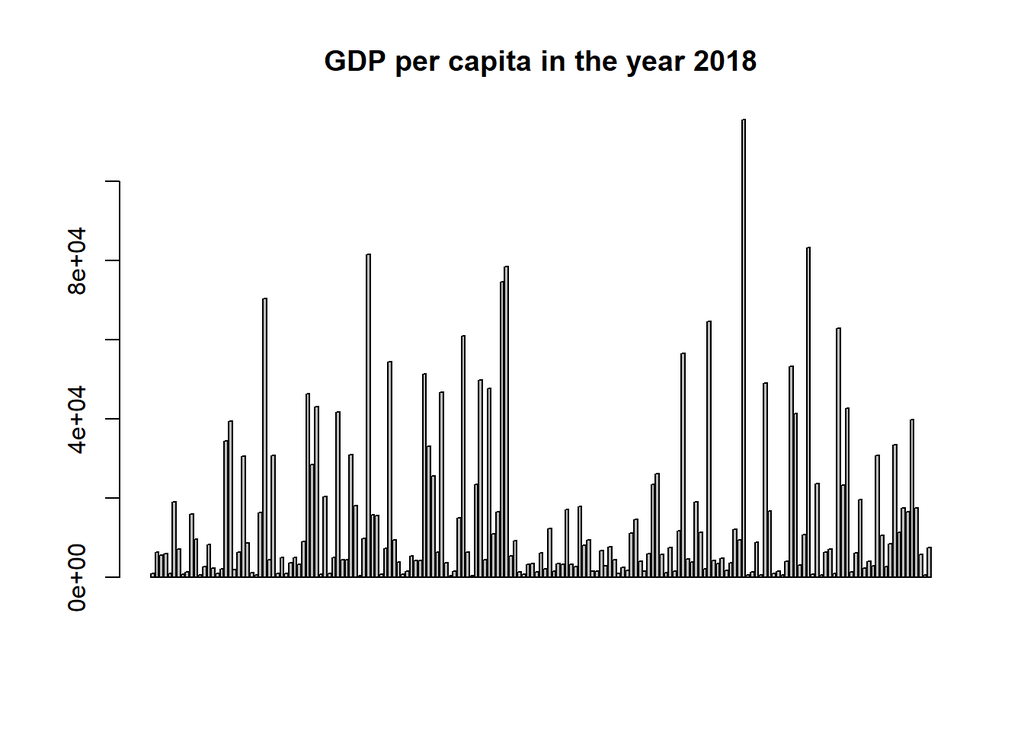

```r
#FOR 2018
barplot(DF1$GDP_percapita, main="GDP per capita in the year 2018")
```

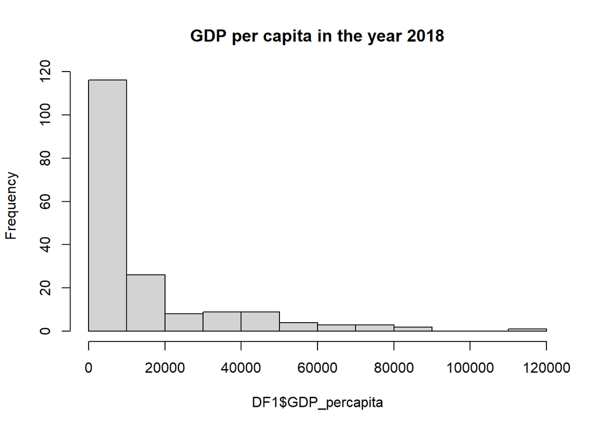

```r
hist(DF1$GDP_percapita, main="GDP per capita in the year 2018")
```